# Exercise 1: Practicing Base R Plotting

Zachary Harel

11/5/26

Load required libraries, the `msleep` dataset, and set the output directory.

```r
library(ggplot2)

data(msleep)

# output dir
dir <- file.path("exer_1")
```

## Task 1: Create and customize a scatterplot

Create a scatterplot of `sleep_total` vs `bodywt` (body weight). Customize your plot with:

- A point character (pch) of your choice
- Blue colored points
- Axis labels: “Body Weight (kg)” for x-axis and “Total Sleep (hours)” for y-axis
- A border style of your choice (bty)

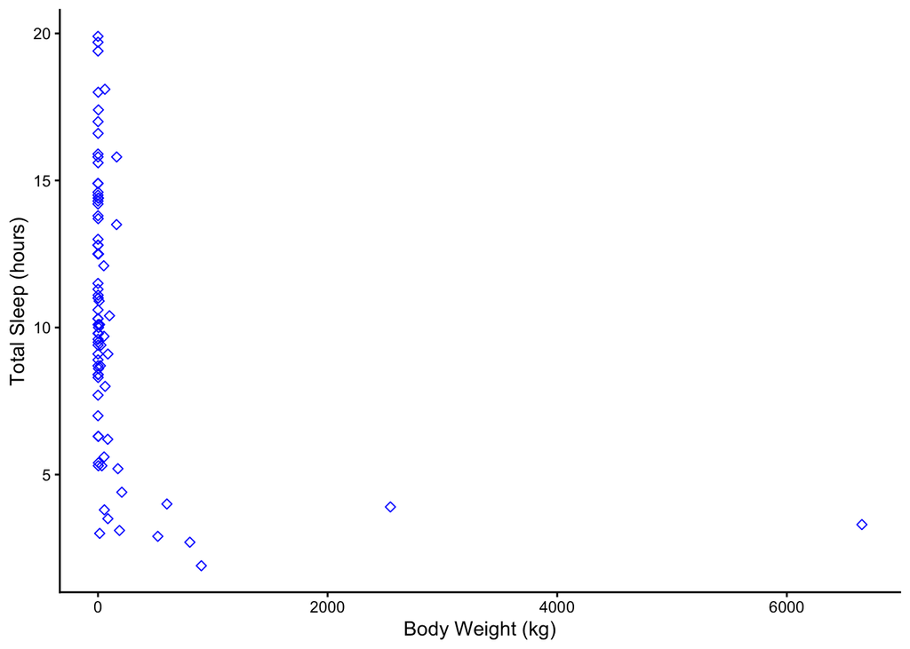

```r
scatter <- ggplot(msleep, aes(x = bodywt, y = sleep_total)) +
  geom_point(color = "blue", shape = 5) +
  labs(x = "Body Weight (kg)", y = "Total Sleep (hours)") +
  theme_classic()
ggsave(file.path(dir, "scatterplot.jpeg"), plot = scatter)
scatter
```

## Task 2: Make a histogram

Create a histogram of the `brainwt` (brain weight) variable. Customize your histogram with:

- A color of your choice (col)
- An appropriate x-axis label
- A descriptive title using the main argument

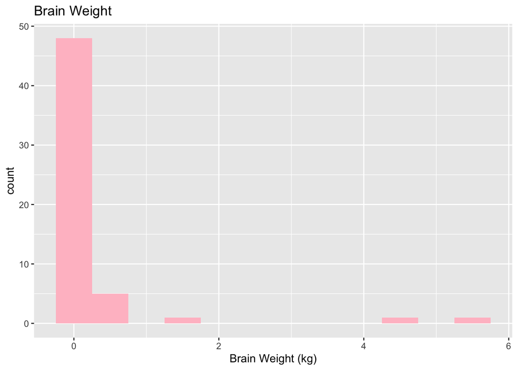

```r
hist <- ggplot(msleep, aes(x = brainwt)) +
  geom_histogram(binwidth = 0.5, fill = "pink", na.rm = TRUE) +
  labs(x = "Brain Weight (kg)", title = "Brain Weight")
ggsave(file.path(dir, "histogram.jpeg"), plot = hist)
hist
```

## Task 3: Create a boxplot comparing groups

Create a boxplot showing `sleep_total` for each `vore` type (diet). Customize your boxplot with:

- Different colors for each box (hint: use `rainbow()` or choose specific colors)
- Appropriate axis labels
- Convert `vore` to a factor using `as.factor()`

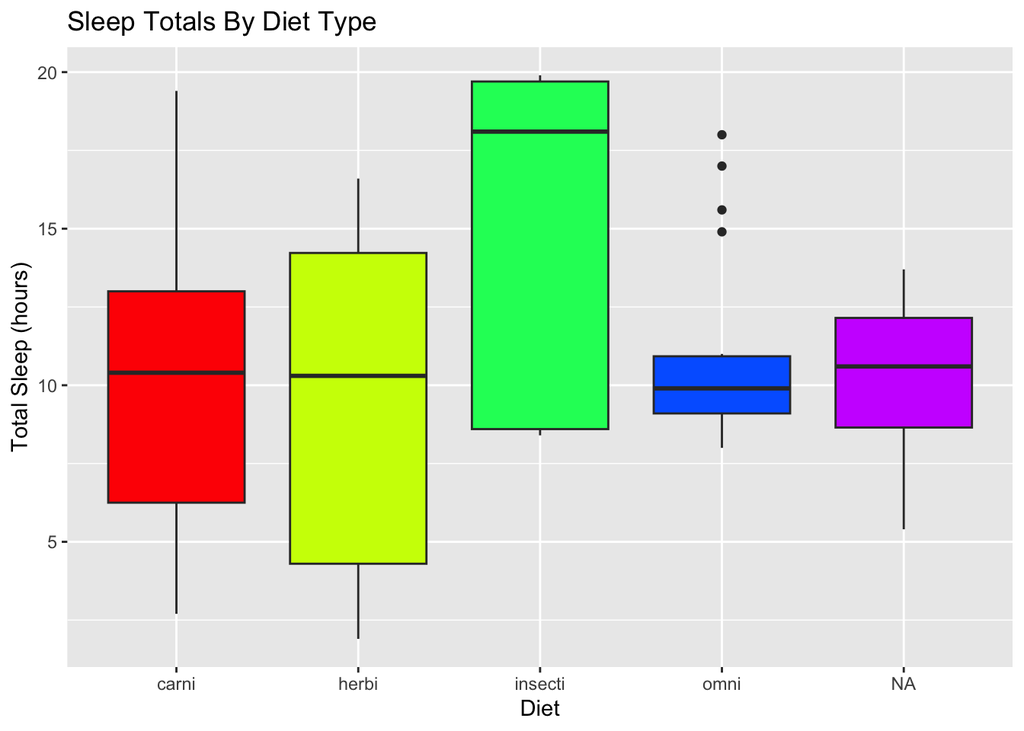

```r
box <- ggplot(msleep, aes(x = as.factor(vore), y = sleep_total)) +
  geom_boxplot(fill = rainbow(length(unique(msleep$vore)))) +
  labs(x = "Diet", y = "Total Sleep (hours)", title = "Sleep Totals By Diet Type")
ggsave(file.path(dir, "boxplot.jpeg"), plot = box)
box
```

## Bonus Challenge (Optional)

Create a scatterplot of any two continuous variables from `msleep`. Add a line of best fit using `abline()` and `lm()`. Color points based on a condition you define (like we did with `sleep_total >= 17` in the tutorial), and add a legend to explain the colors.